# EXAMEN_PARCIAL_DE_ESTADÍSTICA_SEGUNDA_PARTE_DYMM

$$ $$

$$ \large{ \begin{array} {rcr} &\mbox{UNIVERSIDAD AUTÓNOMA DE COAHUILA}& \\ &\mbox{FACULTAD DE SISTEMAS}& \\ &\mbox{ESTADÍSTICA} & \\ &\mbox{Parcial 1. segunda parte}& \\ &\mbox{Jesus Cedillo Reyna} \\ \end{array} } $$

$$ $$ En el archivo **Educacion_modificada.xlsx** se muestra el grado promedio de escolaridad de la población de 15 años o más, dado por entidad federativa según sexo. Los años en los que se realizaron estos estudios fueron del 2000 a 2020 y se tomó como referencia un muestreo aleatorio simple para la obtención de los datos en cada entidad federativa y el tamaño de muestra en cada uno de los estados fue de $1000$ personas.

$\bullet $ Definición:

El Número de años que, en promedio, aprobaron las personas de 15 años o más, en el Sistema Educativo Nacional. Resulta de dividir la suma de los años aprobados desde el primero de primaria hasta el último grado alcanzado de las personas de 15 años o más entre el total de la población de 15 años o más.

$$ $$

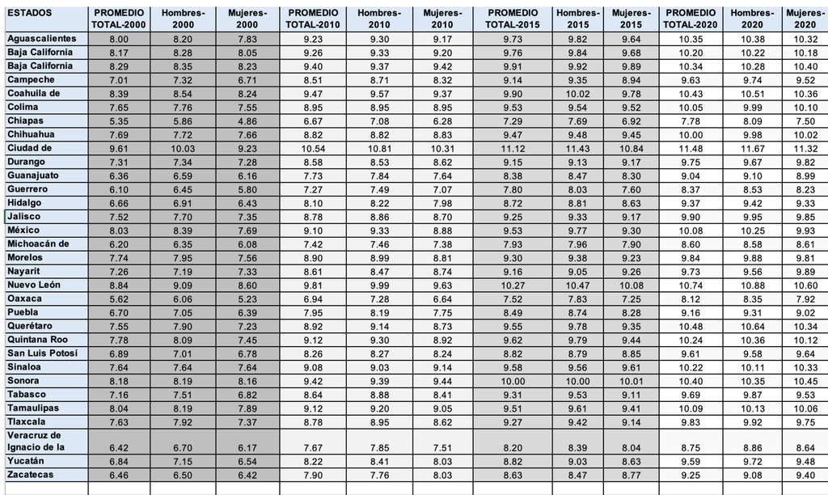

*TLC* :

*Si $X_1,X_2,\ldots,X_n$ es una secuencias de $n$ variables independientes con $\ \ E(X_i)=\mu_i$, $ \ \ \ V(X_i)=\sigma_i^2 \hspace{1cm} $ con $\hspace{1cm}Y=X_1+X_2+\cdots+X_n \hspace{1cm}$ Entonces bajo ciertas condiciones generales se tiene:* $$ $$ $$ \displaystyle Y \sim \cal{Normal}\left(\sum_{i=1}^n \mu_i,\displaystyle \sqrt{ \sum_{i=1}^n \sigma_i^2 }\right) $$ $$ $$

$$Z_n=\frac{Y- \displaystyle \sum_{i=1}^n \mu_i}{ \sqrt{ \displaystyle \sum_{i=1}^n \sigma_i^2}}$$ $$ Z_n \sim \cal{Normal}\left(0,1\right)$$

**Resultado directo** *Si $X_1,X_2,\ldots,X_n$ es una secuencias de $n$ variables INDEPENDIENTES e IDENTICAMENTE DISTRIBUIDAS *(i.i.d.)*,* con $\ \ E(X_i)=\mu$, $ \ \ \ V(X_i)=\sigma^2 \ \ $ Entonces

$$ $$

$\ \ \ Y=X_1+X_2+\cdots+X_n \hspace{1cm}$ *Entonces bajo ciertas condiciones generales se tiene:*

$$ \begin{array}{rcl} Z & = & \displaystyle \frac{x-\mu}{ \sigma }\sim N(0,1) \\ \end{array} $$

\begin{array}{rcl} &&\\ Z_n=\displaystyle \frac{Y- \displaystyle \sum_{i=1}^n \mu_i}{ \sqrt{ \displaystyle \sum_{i=1}^n \sigma_i^2}} & == \Longrightarrow & \displaystyle \frac{Y- \displaystyle n \mu}{ \sqrt{ \displaystyle n \sigma^2}}\\ & & \\ Z_n &=& \displaystyle \frac{\left(\frac{1}{n}\right)(Y- \displaystyle n \mu)}{\left(\frac{1}{n}\right) \left(\sqrt{ \displaystyle n \sigma^2 }\right)}\\ & &\\ Z_n &=& \displaystyle \frac{\left(\frac{1}{n}\right)(Y- \displaystyle n \mu)}{\frac{ \left(\sqrt{ \displaystyle n \sigma^2 }\right)}{n}}\\ & & \\ Z_n & = &\displaystyle \frac{\bar{Y}- \displaystyle \mu}{\displaystyle\sqrt{\frac{\sigma^2}{n}}}\\ && \\ \end{array}

$$Y=X_1+X_2+\cdots+X_n \hspace{.5cm} = \Longrightarrow \hspace{.5cm} Z_n =\displaystyle \frac{\bar{Y}- \displaystyle \mu}{\displaystyle \frac{\sigma}{\sqrt{n}}}$$

$$ $$

Tiene una distribución normal $ \cal{N(0,1)} $

$$ $$

Link relacionado a [TLC](https://support.minitab.com/es-mx/minitab/18/help-and-how-to/statistics/basic-statistics/supporting-topics/data-concepts/about-the-central-limit-theorem/)

```python
import pandas as pd

fila_inicio_2000 = 15
fila_fin_2000 = 47
fila_inicio_2010 = 47
fila_fin_2010 = 79
fila_inicio_2015 = 79
fila_fin_2015 = 111
fila_inicio_2020 = 111
fila_fin_2020 = 143

filas_a_omitir_2000 = fila_inicio_2000 - 1
filas_a_omitir_2010 = fila_inicio_2010 - 1
filas_a_omitir_2015 = fila_inicio_2015 - 1
filas_a_omitir_2020 = fila_inicio_2020 - 1

df_2000 = pd.read_excel('Educacion_modificada.xlsx', skiprows=filas_a_omitir_2000, nrows=fila_fin_2000 - filas_a_omitir_2000 - 1)
df_2010 = pd.read_excel('Educacion_modificada.xlsx', skiprows=filas_a_omitir_2010, nrows=fila_fin_2010 - filas_a_omitir_2010 - 1)
df_2015 = pd.read_excel('Educacion_modificada.xlsx', skiprows=filas_a_omitir_2015, nrows=fila_fin_2015 - filas_a_omitir_2015 - 1)
df_2020 = pd.read_excel('Educacion_modificada.xlsx', skiprows=filas_a_omitir_2020, nrows=fila_fin_2020 - filas_a_omitir_2020 - 1)

df_2010.columns = df_2000.columns
df_2015.columns = df_2000.columns
df_2020.columns = df_2000.columns
```

```python
print("Ano 2000")
df_2000
```

```
Ano 2000
```

|  | ESTADOS | PROMEDIO TOTAL | Hombres | Mujeres |
| --- | --- | --- | --- | --- |
| 0 | Aguascalientes | 8.00 | 8.20 | 7.83 |
| 1 | Baja California | 8.17 | 8.28 | 8.05 |
| 2 | Baja California Sur | 8.29 | 8.35 | 8.23 |
| 3 | Campeche | 7.01 | 7.32 | 6.71 |
| 4 | Coahuila de Zaragoza | 8.39 | 8.54 | 8.24 |
| 5 | Colima | 7.65 | 7.76 | 7.55 |
| 6 | Chiapas | 5.35 | 5.86 | 4.86 |
| 7 | Chihuahua | 7.69 | 7.72 | 7.66 |
| 8 | Ciudad de México | 9.61 | 10.03 | 9.23 |
| 9 | Durango | 7.31 | 7.34 | 7.28 |
| 10 | Guanajuato | 6.36 | 6.59 | 6.16 |
| 11 | Guerrero | 6.10 | 6.45 | 5.80 |
| 12 | Hidalgo | 6.66 | 6.91 | 6.43 |
| 13 | Jalisco | 7.52 | 7.70 | 7.35 |
| 14 | México | 8.03 | 8.39 | 7.69 |
| 15 | Michoacán de Ocampo | 6.20 | 6.35 | 6.08 |
| 16 | Morelos | 7.74 | 7.95 | 7.56 |
| 17 | Nayarit | 7.26 | 7.19 | 7.33 |
| 18 | Nuevo León | 8.84 | 9.09 | 8.60 |
| 19 | Oaxaca | 5.62 | 6.06 | 5.23 |
| 20 | Puebla | 6.70 | 7.05 | 6.39 |
| 21 | Querétaro | 7.55 | 7.90 | 7.23 |
| 22 | Quintana Roo | 7.78 | 8.09 | 7.45 |
| 23 | San Luis Potosí | 6.89 | 7.01 | 6.78 |
| 24 | Sinaloa | 7.64 | 7.64 | 7.64 |
| 25 | Sonora | 8.18 | 8.19 | 8.16 |
| 26 | Tabasco | 7.16 | 7.51 | 6.82 |
| 27 | Tamaulipas | 8.04 | 8.19 | 7.89 |
| 28 | Tlaxcala | 7.63 | 7.92 | 7.37 |
| 29 | Veracruz de Ignacio de la Llave | 6.42 | 6.70 | 6.17 |
| 30 | Yucatán | 6.84 | 7.15 | 6.54 |
| 31 | Zacatecas | 6.46 | 6.50 | 6.42 |

```python
print("Ano 2010")
df_2010
```

```
Ano 2010
```

|  | ESTADOS | PROMEDIO TOTAL | Hombres | Mujeres |
| --- | --- | --- | --- | --- |
| 0 | Aguascalientes | 9.23 | 9.30 | 9.17 |
| 1 | Baja California | 9.26 | 9.33 | 9.20 |
| 2 | Baja California Sur | 9.40 | 9.37 | 9.42 |
| 3 | Campeche | 8.51 | 8.71 | 8.32 |
| 4 | Coahuila de Zaragoza | 9.47 | 9.57 | 9.37 |
| 5 | Colima | 8.95 | 8.95 | 8.95 |
| 6 | Chiapas | 6.67 | 7.08 | 6.28 |
| 7 | Chihuahua | 8.82 | 8.82 | 8.83 |
| 8 | Ciudad de México | 10.54 | 10.81 | 10.31 |
| 9 | Durango | 8.58 | 8.53 | 8.62 |
| 10 | Guanajuato | 7.73 | 7.84 | 7.64 |
| 11 | Guerrero | 7.27 | 7.49 | 7.07 |
| 12 | Hidalgo | 8.10 | 8.22 | 7.98 |
| 13 | Jalisco | 8.78 | 8.86 | 8.70 |
| 14 | México | 9.10 | 9.33 | 8.88 |
| 15 | Michoacán de Ocampo | 7.42 | 7.46 | 7.38 |
| 16 | Morelos | 8.90 | 8.99 | 8.81 |
| 17 | Nayarit | 8.61 | 8.47 | 8.74 |
| 18 | Nuevo León | 9.81 | 9.99 | 9.63 |
| 19 | Oaxaca | 6.94 | 7.28 | 6.64 |
| 20 | Puebla | 7.95 | 8.19 | 7.75 |
| 21 | Querétaro | 8.92 | 9.14 | 8.73 |
| 22 | Quintana Roo | 9.12 | 9.30 | 8.92 |
| 23 | San Luis Potosí | 8.26 | 8.27 | 8.24 |
| 24 | Sinaloa | 9.08 | 9.03 | 9.14 |
| 25 | Sonora | 9.42 | 9.39 | 9.44 |
| 26 | Tabasco | 8.64 | 8.88 | 8.41 |
| 27 | Tamaulipas | 9.12 | 9.20 | 9.05 |
| 28 | Tlaxcala | 8.78 | 8.95 | 8.62 |
| 29 | Veracruz de Ignacio de la Llave | 7.67 | 7.85 | 7.51 |
| 30 | Yucatán | 8.22 | 8.41 | 8.03 |
| 31 | Zacatecas | 7.90 | 7.76 | 8.03 |

```python
print("Ano 2015")
df_2015
```

```
Ano 2015
```

|  | ESTADOS | PROMEDIO TOTAL | Hombres | Mujeres |
| --- | --- | --- | --- | --- |
| 0 | Aguascalientes | 9.73 | 9.82 | 9.64 |
| 1 | Baja California | 9.76 | 9.84 | 9.68 |
| 2 | Baja California Sur | 9.91 | 9.92 | 9.89 |
| 3 | Campeche | 9.14 | 9.35 | 8.94 |
| 4 | Coahuila de Zaragoza | 9.90 | 10.02 | 9.78 |
| 5 | Colima | 9.53 | 9.54 | 9.52 |
| 6 | Chiapas | 7.29 | 7.69 | 6.92 |
| 7 | Chihuahua | 9.47 | 9.48 | 9.45 |
| 8 | Ciudad de México | 11.12 | 11.43 | 10.84 |
| 9 | Durango | 9.15 | 9.13 | 9.17 |
| 10 | Guanajuato | 8.38 | 8.47 | 8.30 |
| 11 | Guerrero | 7.80 | 8.03 | 7.60 |
| 12 | Hidalgo | 8.72 | 8.81 | 8.63 |
| 13 | Jalisco | 9.25 | 9.33 | 9.17 |
| 14 | México | 9.53 | 9.77 | 9.30 |
| 15 | Michoacán de Ocampo | 7.93 | 7.96 | 7.90 |
| 16 | Morelos | 9.30 | 9.38 | 9.23 |
| 17 | Nayarit | 9.16 | 9.05 | 9.26 |
| 18 | Nuevo León | 10.27 | 10.47 | 10.08 |
| 19 | Oaxaca | 7.52 | 7.83 | 7.25 |
| 20 | Puebla | 8.49 | 8.74 | 8.28 |
| 21 | Querétaro | 9.55 | 9.78 | 9.35 |
| 22 | Quintana Roo | 9.62 | 9.79 | 9.44 |
| 23 | San Luis Potosí | 8.82 | 8.79 | 8.85 |
| 24 | Sinaloa | 9.58 | 9.56 | 9.61 |
| 25 | Sonora | 10.00 | 10.00 | 10.01 |
| 26 | Tabasco | 9.31 | 9.53 | 9.11 |
| 27 | Tamaulipas | 9.51 | 9.61 | 9.41 |
| 28 | Tlaxcala | 9.27 | 9.42 | 9.14 |
| 29 | Veracruz de Ignacio de la Llave | 8.20 | 8.39 | 8.04 |
| 30 | Yucatán | 8.82 | 9.03 | 8.63 |
| 31 | Zacatecas | 8.63 | 8.47 | 8.77 |

```python
print("Ano 2020")
df_2020
```

```
Ano 2020
```

|  | ESTADOS | PROMEDIO TOTAL | Hombres | Mujeres |
| --- | --- | --- | --- | --- |
| 0 | Aguascalientes | 10.35 | 10.38 | 10.32 |
| 1 | Baja California | 10.20 | 10.22 | 10.18 |
| 2 | Baja California Sur | 10.34 | 10.28 | 10.40 |
| 3 | Campeche | 9.63 | 9.74 | 9.52 |
| 4 | Coahuila de Zaragoza | 10.43 | 10.51 | 10.36 |
| 5 | Colima | 10.05 | 9.99 | 10.10 |
| 6 | Chiapas | 7.78 | 8.09 | 7.50 |
| 7 | Chihuahua | 10.00 | 9.98 | 10.02 |
| 8 | Ciudad de México | 11.48 | 11.67 | 11.32 |
| 9 | Durango | 9.75 | 9.67 | 9.82 |
| 10 | Guanajuato | 9.04 | 9.10 | 8.99 |
| 11 | Guerrero | 8.37 | 8.53 | 8.23 |
| 12 | Hidalgo | 9.37 | 9.42 | 9.33 |
| 13 | Jalisco | 9.90 | 9.95 | 9.85 |
| 14 | México | 10.08 | 10.25 | 9.93 |
| 15 | Michoacán de Ocampo | 8.60 | 8.58 | 8.61 |
| 16 | Morelos | 9.84 | 9.88 | 9.81 |
| 17 | Nayarit | 9.73 | 9.56 | 9.89 |
| 18 | Nuevo León | 10.74 | 10.88 | 10.60 |
| 19 | Oaxaca | 8.12 | 8.35 | 7.92 |
| 20 | Puebla | 9.16 | 9.31 | 9.02 |
| 21 | Querétaro | 10.48 | 10.64 | 10.34 |
| 22 | Quintana Roo | 10.24 | 10.36 | 10.12 |
| 23 | San Luis Potosí | 9.61 | 9.58 | 9.64 |
| 24 | Sinaloa | 10.22 | 10.11 | 10.33 |
| 25 | Sonora | 10.40 | 10.35 | 10.45 |
| 26 | Tabasco | 9.69 | 9.87 | 9.53 |
| 27 | Tamaulipas | 10.09 | 10.13 | 10.06 |
| 28 | Tlaxcala | 9.83 | 9.92 | 9.75 |
| 29 | Veracruz de Ignacio de la Llave | 8.75 | 8.86 | 8.64 |
| 30 | Yucatán | 9.59 | 9.72 | 9.48 |
| 31 | Zacatecas | 9.25 | 9.08 | 9.40 |

1. Usando como referencia los de datos del archivo **Educacion_modificada.xlsx**

a) Realice una representación gráfica que involucre los histogramas asociados a Hombres-2000, Hombres-2010, Hombres-2015, Hombres-2020 (en una sola ventana de graficación.)  
b) Realice una representación gráfica que involucre los histogramas asociados a Mujeres-2000, Mujeres-2010, Mujeres-2015, Mujeres-2020 (en una sola ventana de graficación.)

# :

```python
df_2000.describe()
```

|  | PROMEDIO TOTAL | Hombres | Mujeres |
| --- | --- | --- | --- |
| count | 32.000000 | 32.000000 | 32.000000 |
| mean | 7.346563 | 7.560313 | 7.147813 |
| std | 0.930410 | 0.902429 | 0.971466 |
| min | 5.350000 | 5.860000 | 4.860000 |
| 25% | 6.690000 | 6.985000 | 6.427500 |
| 50% | 7.535000 | 7.670000 | 7.340000 |
| 75% | 8.007500 | 8.190000 | 7.725000 |
| max | 9.610000 | 10.030000 | 9.230000 |

```python
df_2010.describe()
```

|  | PROMEDIO TOTAL | Hombres | Mujeres |
| --- | --- | --- | --- |
| count | 32.000000 | 32.000000 | 32.000000 |
| mean | 8.599063 | 8.711562 | 8.494063 |
| std | 0.847674 | 0.822491 | 0.886952 |
| min | 6.670000 | 7.080000 | 6.280000 |
| 25% | 8.062500 | 8.212500 | 8.017500 |
| 50% | 8.780000 | 8.870000 | 8.715000 |
| 75% | 9.120000 | 9.300000 | 9.072500 |
| max | 10.540000 | 10.810000 | 10.310000 |

```python
df_2015.describe()
```

|  | PROMEDIO TOTAL | Hombres | Mujeres |
| --- | --- | --- | --- |
| count | 32.000000 | 32.000000 | 32.000000 |
| mean | 9.145625 | 9.263438 | 9.037187 |
| std | 0.821026 | 0.806936 | 0.847601 |
| min | 7.290000 | 7.690000 | 6.920000 |
| 25% | 8.697500 | 8.777500 | 8.630000 |
| 50% | 9.285000 | 9.400000 | 9.200000 |
| 75% | 9.590000 | 9.782500 | 9.542500 |
| max | 11.120000 | 11.430000 | 10.840000 |

```python
df_2020.describe()
```

|  | PROMEDIO TOTAL | Hombres | Mujeres |
| --- | --- | --- | --- |
| count | 32.000000 | 32.000000 | 32.000000 |
| mean | 9.722188 | 9.780000 | 9.670625 |
| std | 0.787535 | 0.767926 | 0.819378 |
| min | 7.780000 | 8.090000 | 7.500000 |
| 25% | 9.340000 | 9.392500 | 9.382500 |
| 50% | 9.835000 | 9.900000 | 9.835000 |
| 75% | 10.225000 | 10.257500 | 10.215000 |
| max | 11.480000 | 11.670000 | 11.320000 |

# a)

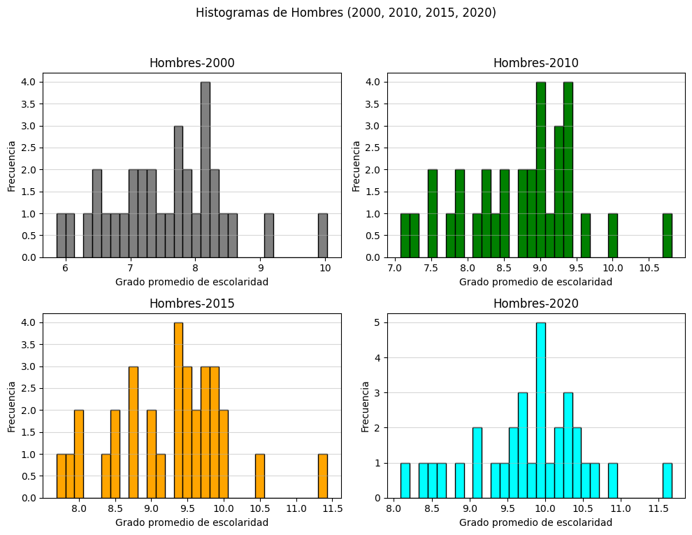

```python
import matplotlib.pyplot as plt

plt.figure(figsize=(10, 8))

plt.subplot(2, 2, 1)
plt.hist(df_2000['Hombres'], bins=30, color='gray', edgecolor='black')
plt.title('Hombres-2000')
plt.xlabel('Grado promedio de escolaridad')
plt.ylabel('Frecuencia')
plt.grid(axis='y', alpha=0.5)

plt.subplot(2, 2, 2)
plt.hist(df_2010['Hombres'], bins=30, color='green', edgecolor='black')
plt.title('Hombres-2010')
plt.xlabel('Grado promedio de escolaridad')
plt.ylabel('Frecuencia')
plt.grid(axis='y', alpha=0.5)

plt.subplot(2, 2, 3)
plt.hist(df_2015['Hombres'], bins=30, color='orange', edgecolor='black')
plt.title('Hombres-2015')
plt.xlabel('Grado promedio de escolaridad')
plt.ylabel('Frecuencia')
plt.grid(axis='y', alpha=0.5)

plt.subplot(2, 2, 4)
plt.hist(df_2020['Hombres'], bins=30, color='aqua', edgecolor='black')
plt.title('Hombres-2020')
plt.xlabel('Grado promedio de escolaridad')
plt.ylabel('Frecuencia')
plt.grid(axis='y', alpha=0.5)

plt.suptitle('Histogramas de Hombres (2000, 2010, 2015, 2020)')
plt.tight_layout(rect=[0, 0.03, 1, 0.95])
plt.show()
```

# b)

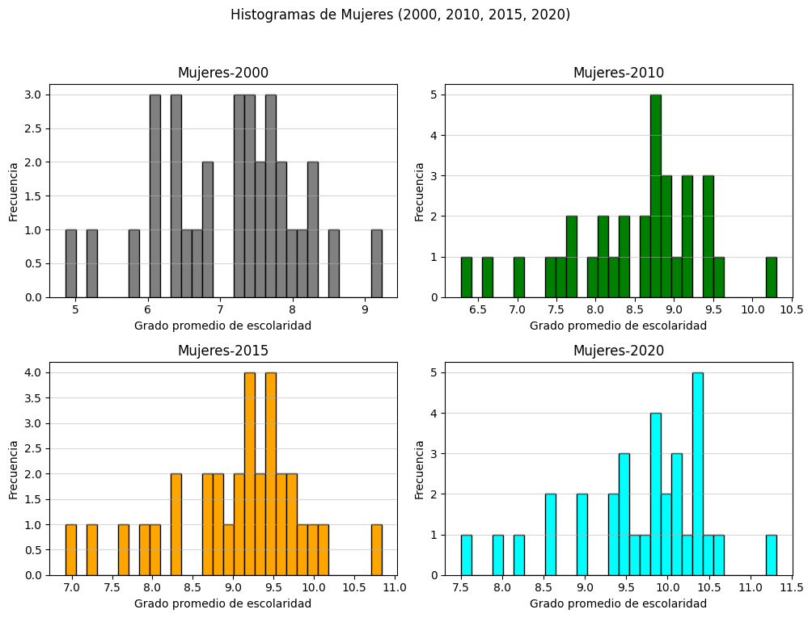

```python
import matplotlib.pyplot as plt

plt.figure(figsize=(10, 8))

plt.subplot(2, 2, 1)
plt.hist(df_2000['Mujeres'], bins=30, color='gray', edgecolor='black')
plt.title('Mujeres-2000')
plt.xlabel('Grado promedio de escolaridad')
plt.ylabel('Frecuencia')
plt.grid(axis='y', alpha=0.5)

plt.subplot(2, 2, 2)
plt.hist(df_2010['Mujeres'], bins=30, color='green', edgecolor='black')
plt.title('Mujeres-2010')
plt.xlabel('Grado promedio de escolaridad')
plt.ylabel('Frecuencia')
plt.grid(axis='y', alpha=0.5)

plt.subplot(2, 2, 3)
plt.hist(df_2015['Mujeres'], bins=30, color='orange', edgecolor='black')
plt.title('Mujeres-2015')
plt.xlabel('Grado promedio de escolaridad')
plt.ylabel('Frecuencia')
plt.grid(axis='y', alpha=0.5)

plt.subplot(2, 2, 4)
plt.hist(df_2020['Mujeres'], bins=30, color='aqua', edgecolor='black')
plt.title('Mujeres-2020')
plt.xlabel('Grado promedio de escolaridad')
plt.ylabel('Frecuencia')
plt.grid(axis='y', alpha=0.5)

plt.suptitle('Histogramas de Mujeres (2000, 2010, 2015, 2020)')
plt.tight_layout(rect=[0, 0.03, 1, 0.95])
plt.show()
```

```python
df_combined = pd.concat([df_2000, df_2010, df_2015, df_2020])
df_combined.describe()
```

|  | PROMEDIO TOTAL | Hombres | Mujeres |
| --- | --- | --- | --- |
| count | 128.000000 | 128.000000 | 128.000000 |
| mean | 8.703359 | 8.828828 | 8.587422 |
| std | 1.216572 | 1.162442 | 1.277748 |
| min | 5.350000 | 5.860000 | 4.860000 |
| 25% | 7.795000 | 8.012500 | 7.655000 |
| 50% | 8.830000 | 8.970000 | 8.790000 |
| 75% | 9.610000 | 9.725000 | 9.520000 |
| max | 11.480000 | 11.670000 | 11.320000 |

2. Usando como referencia los de datos del archivo **Educacion_modificada.xlsx**

a) Realice una representación gráfica que involucre los gráficos de cajas (BOXPLOT) asociados a *Hombres-2000*, *Hombres-2010*, *Hombres-2015*, *Hombres-2020* (en una sola ventana de graficación.)  
b) Realice una representación gráfica que involucre los gráficos de cajas (BOXPLOT) asociados a *Mujeres-2000*, *Mujeres-2010*, *Mujeres-2015*, *Mujeres-2020* (en una sola ventana de graficación.)

c) Realice una representación gráfica que involucre los gráficos de cajas (BOXPLOT) usando el siguiente orden: *Hombres-2000*, *Mujeres-2000*, *Hombres-2010*, *Mujeres-2010*, *Hombres-2015*, *Mujeres-2015*, *Hombres-2020*, *Mujeres-2020* (en una sola ventana de graficación.)

# a)

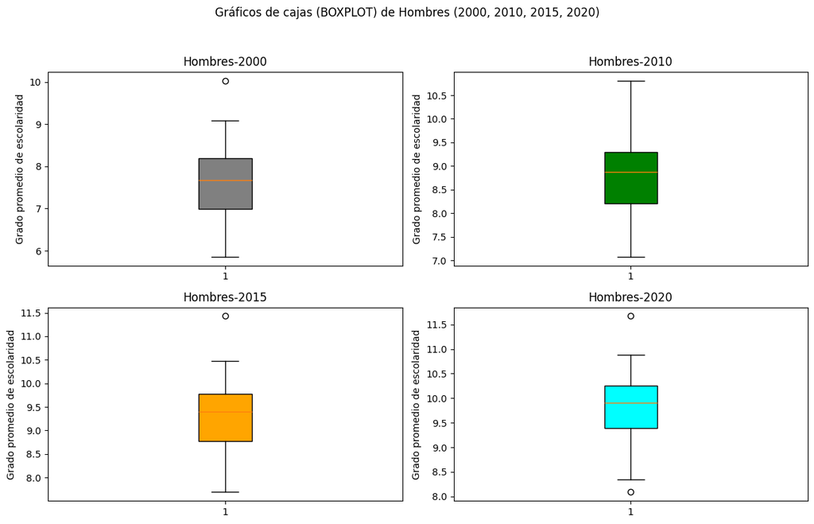

```python
import matplotlib.pyplot as plt

plt.figure(figsize=(12, 8))

plt.subplot(2, 2, 1)
plt.boxplot(df_2000['Hombres'], patch_artist=True, boxprops=dict(facecolor='gray'))
plt.title('Hombres-2000')
plt.ylabel('Grado promedio de escolaridad')

plt.subplot(2, 2, 2)
plt.boxplot(df_2010['Hombres'], patch_artist=True, boxprops=dict(facecolor='green'))
plt.title('Hombres-2010')
plt.ylabel('Grado promedio de escolaridad')

plt.subplot(2, 2, 3)
plt.boxplot(df_2015['Hombres'], patch_artist=True, boxprops=dict(facecolor='orange'))
plt.title('Hombres-2015')
plt.ylabel('Grado promedio de escolaridad')

plt.subplot(2, 2, 4)
plt.boxplot(df_2020['Hombres'], patch_artist=True, boxprops=dict(facecolor='aqua'))
plt.title('Hombres-2020')
plt.ylabel('Grado promedio de escolaridad')

plt.suptitle('Gráficos de cajas (BOXPLOT) de Hombres (2000, 2010, 2015, 2020)')
plt.tight_layout(rect=[0, 0.03, 1, 0.95])
plt.show()
```

# b)

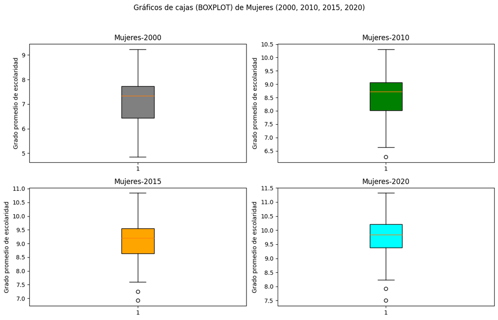

```python
plt.figure(figsize=(12, 8))

plt.subplot(2, 2, 1)
plt.boxplot(df_2000['Mujeres'], patch_artist=True, boxprops=dict(facecolor='gray'))
plt.title('Mujeres-2000')
plt.ylabel('Grado promedio de escolaridad')

plt.subplot(2, 2, 2)
plt.boxplot(df_2010['Mujeres'], patch_artist=True, boxprops=dict(facecolor='green'))
plt.title('Mujeres-2010')
plt.ylabel('Grado promedio de escolaridad')

plt.subplot(2, 2, 3)
plt.boxplot(df_2015['Mujeres'], patch_artist=True, boxprops=dict(facecolor='orange'))
plt.title('Mujeres-2015')
plt.ylabel('Grado promedio de escolaridad')

plt.subplot(2, 2, 4)
plt.boxplot(df_2020['Mujeres'], patch_artist=True, boxprops=dict(facecolor='aqua'))
plt.title('Mujeres-2020')
plt.ylabel('Grado promedio de escolaridad')

plt.suptitle('Gráficos de cajas (BOXPLOT) de Mujeres (2000, 2010, 2015, 2020)')
plt.tight_layout(rect=[0, 0.03, 1, 0.95])
plt.show()
```

# C)

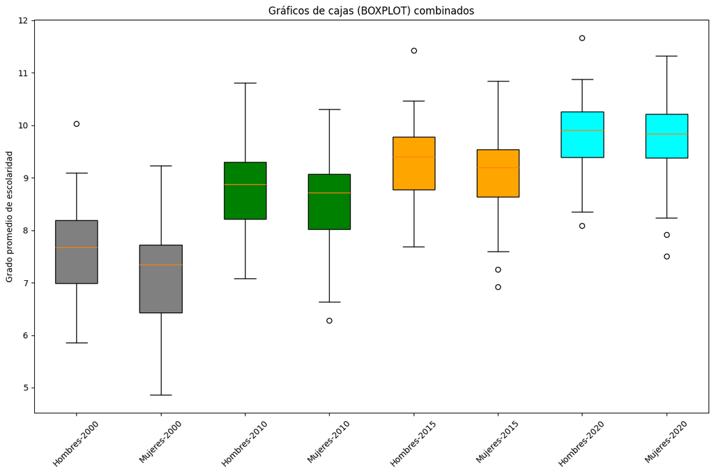

```python
data_to_plot = [df_2000['Hombres'], df_2000['Mujeres'], df_2010['Hombres'], df_2010['Mujeres'], df_2015['Hombres'], df_2015['Mujeres'], df_2020['Hombres'], df_2020['Mujeres']]
colors = ['gray', 'gray', 'green', 'green', 'orange', 'orange', 'aqua', 'aqua']
labels = ['Hombres-2000', 'Mujeres-2000', 'Hombres-2010', 'Mujeres-2010', 'Hombres-2015', 'Mujeres-2015', 'Hombres-2020', 'Mujeres-2020']

fig = plt.figure(figsize=(12, 8))
boxplots = plt.boxplot(data_to_plot, patch_artist=True)

for patch, color in zip(boxplots['boxes'], colors):
    patch.set_facecolor(color)

plt.xticks(range(1, len(labels) + 1), labels)
plt.title('Gráficos de cajas (BOXPLOT) combinados')
plt.ylabel('Grado promedio de escolaridad')
plt.xticks(rotation=45)
plt.tight_layout()
plt.show()
```

3. Usando como referencia los datos del archivo **Educacion_modificada.xlsx**

a) Realice una representación gráfica que involucre los intervalos de confianza asociados a *Hombres-2000*, *Hombres-2010*, *Hombres-2015*, *Hombres-2020* (en una sola ventana de graficación.)  
b) Realice una representación gráfica que involucre los intervalos de confianza asociados a *Mujeres-2000*, *Mujeres-2010*, *Mujeres-2015*, *Mujeres-2020* (en una sola ventana de graficación.)

# a)

```
Intervalo de confianza para Hombres-2000: (7.234952305862771, 7.885672694137229)
Intervalo de confianza para Hombres-2010: (8.415022963497535, 9.008102036502464)
Intervalo de confianza para Hombres-2015: (8.97250601219285, 9.55436898780715)
Intervalo de confianza para Hombres-2020: (9.503133308383745, 10.056866691616257)
```

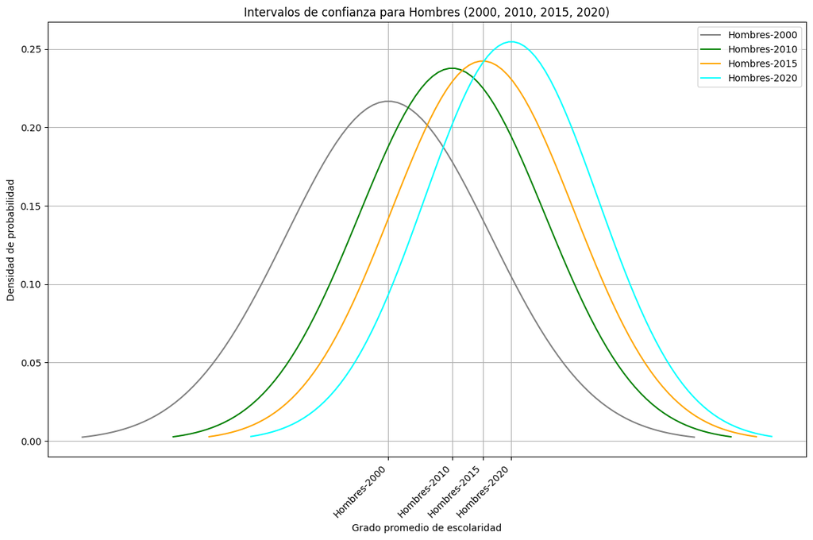

```python
import numpy as np
from scipy import stats
import matplotlib.pyplot as plt
from scipy.stats import norm

def intervalo_confianza(data, alpha=0.05):
    media = np.mean(data)
    sem = stats.sem(data)
    intervalo = stats.t.interval(1-alpha, len(data)-1, loc=media, scale=sem)
    return media, intervalo

media_hombres_2000, intervalo_hombres_2000 = intervalo_confianza(df_2000['Hombres'])
media_hombres_2010, intervalo_hombres_2010 = intervalo_confianza(df_2010['Hombres'])
media_hombres_2015, intervalo_hombres_2015 = intervalo_confianza(df_2015['Hombres'])
media_hombres_2020, intervalo_hombres_2020 = intervalo_confianza(df_2020['Hombres'])

print(f'\nIntervalo de confianza para Hombres-2000: {intervalo_hombres_2000}')
print(f'Intervalo de confianza para Hombres-2010: {intervalo_hombres_2010}')
print(f'Intervalo de confianza para Hombres-2015: {intervalo_hombres_2015}')
print(f'Intervalo de confianza para Hombres-2020: {intervalo_hombres_2020}')

fig, ax = plt.subplots(figsize=(12, 8))

categorias = ['Hombres-2000', 'Hombres-2010', 'Hombres-2015', 'Hombres-2020']
medias = [media_hombres_2000, media_hombres_2010, media_hombres_2015, media_hombres_2020]
errores = [(intervalo_hombres_2000[1]-intervalo_hombres_2000[0])/2,
           (intervalo_hombres_2010[1]-intervalo_hombres_2010[0])/2,
           (intervalo_hombres_2015[1]-intervalo_hombres_2015[0])/2,
           (intervalo_hombres_2020[1]-intervalo_hombres_2020[0])/2]

colores = ['gray', 'green', 'orange', 'aqua']

for i, categoria in enumerate(categorias):
    media = medias[i]
    error = errores[i]
    desv = error * np.sqrt(len(df_2000))  # Desviación estándar aproximada
    x = np.linspace(media - 3*desv, media + 3*desv, 100)
    y = norm.pdf(x, media, desv)
    ax.plot(x, y, label=categoria, color=colores[i])

ax.set_xticks(medias)
ax.set_xticklabels(categorias, rotation=45, ha='right')
ax.set_title('Intervalos de confianza para Hombres (2000, 2010, 2015, 2020)')
ax.set_xlabel('Grado promedio de escolaridad')
ax.set_ylabel('Densidad de probabilidad')
ax.legend()
ax.grid(True)

plt.tight_layout()
plt.show()
```

# b)

```
Intervalo de confianza para Mujeres-2000: (6.797561567125698, 7.498063432874303)
Intervalo de confianza para Mujeres-2010: (8.174282383493598, 8.813842616506403)
Intervalo de confianza para Mujeres-2015: (8.731594780791065, 9.342780219208935)
Intervalo de confianza para Mujeres-2020: (9.37520774260828, 9.966042257391718)
```

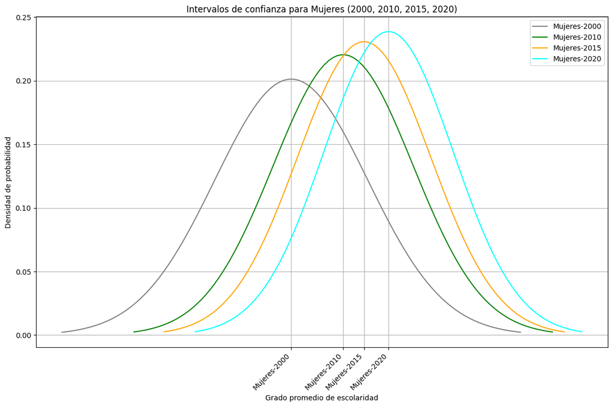

```python
import numpy as np
from scipy import stats
import matplotlib.pyplot as plt
from scipy.stats import norm

def intervalo_confianza(data, alpha=0.05):
    media = np.mean(data)
    sem = stats.sem(data)
    intervalo = stats.t.interval(1-alpha, len(data)-1, loc=media, scale=sem)
    return media, intervalo

media_mujeres_2000, intervalo_mujeres_2000 = intervalo_confianza(df_2000['Mujeres'])
media_mujeres_2010, intervalo_mujeres_2010 = intervalo_confianza(df_2010['Mujeres'])
media_mujeres_2015, intervalo_mujeres_2015 = intervalo_confianza(df_2015['Mujeres'])
media_mujeres_2020, intervalo_mujeres_2020 = intervalo_confianza(df_2020['Mujeres'])

print(f'\nIntervalo de confianza para Mujeres-2000: {intervalo_mujeres_2000}')
print(f'Intervalo de confianza para Mujeres-2010: {intervalo_mujeres_2010}')
print(f'Intervalo de confianza para Mujeres-2015: {intervalo_mujeres_2015}')
print(f'Intervalo de confianza para Mujeres-2020: {intervalo_mujeres_2020}')

fig, ax = plt.subplots(figsize=(12, 8))

categorias = ['Mujeres-2000', 'Mujeres-2010', 'Mujeres-2015', 'Mujeres-2020']
medias = [media_mujeres_2000, media_mujeres_2010, media_mujeres_2015, media_mujeres_2020]
errores = [(intervalo_mujeres_2000[1]-intervalo_mujeres_2000[0])/2,
           (intervalo_mujeres_2010[1]-intervalo_mujeres_2010[0])/2,
           (intervalo_mujeres_2015[1]-intervalo_mujeres_2015[0])/2,
           (intervalo_mujeres_2020[1]-intervalo_mujeres_2020[0])/2]

colores = ['gray', 'green', 'orange', 'aqua']

for i, categoria in enumerate(categorias):
    media = medias[i]
    error = errores[i]
    desv = error * np.sqrt(len(df_2000))
    x = np.linspace(media - 3*desv, media + 3*desv, 100)
    y = norm.pdf(x, media, desv)
    ax.plot(x, y, label=categoria, color=colores[i])

ax.set_xticks(medias)
ax.set_xticklabels(categorias, rotation=45, ha='right')
ax.set_title('Intervalos de confianza para Mujeres (2000, 2010, 2015, 2020)')
ax.set_xlabel('Grado promedio de escolaridad')
ax.set_ylabel('Densidad de probabilidad')
ax.legend()
ax.grid(True)

plt.tight_layout()
plt.show()
```

4. Usando como referencia los datos del archivo **Educacion_modificada.xlsx**

a) Realice una representación gráfica que involucre los histogramas asociados a *Hombres*, *Mujeres* y *PROMEDIO TOTAL* (en una sola ventana de graficación.)

b) Realice una representación gráfica que involucre los intervalos de confianza asociados a *Hombres* y *Mujeres* y *PROMEDIO TOTAL* (en una sola ventana de graficación.)

# a)

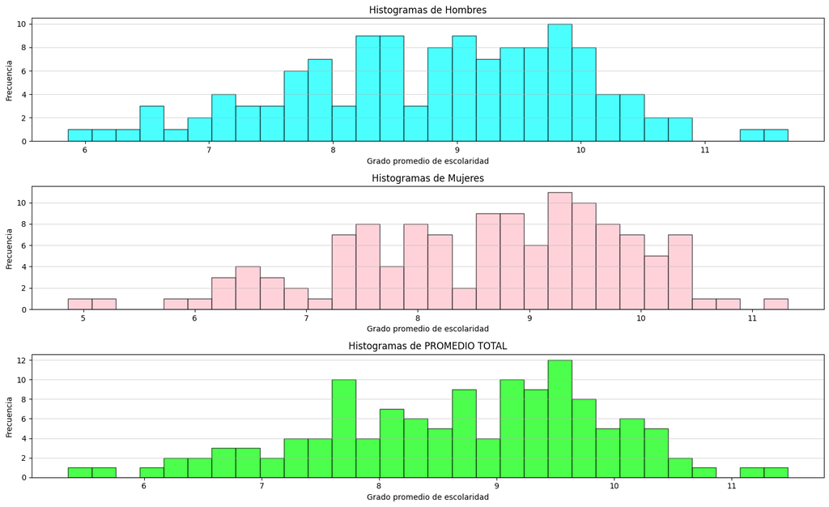

```python
import matplotlib.pyplot as plt

df_combined = pd.concat([df_2000, df_2010, df_2015, df_2020])

plt.figure(figsize=(15, 10))

plt.subplot(3, 1, 1)
plt.hist(df_combined['Hombres'], bins=30, color='aqua', edgecolor='black', alpha=0.7)
plt.title('Histogramas de Hombres')
plt.xlabel('Grado promedio de escolaridad')
plt.ylabel('Frecuencia')
plt.grid(axis='y', alpha=0.5)

plt.subplot(3, 1, 2)
plt.hist(df_combined['Mujeres'], bins=30, color='pink', edgecolor='black', alpha=0.7)
plt.title('Histogramas de Mujeres')
plt.xlabel('Grado promedio de escolaridad')
plt.ylabel('Frecuencia')
plt.grid(axis='y', alpha=0.5)

plt.subplot(3, 1, 3)
plt.hist(df_combined['PROMEDIO TOTAL'], bins=30, color='lime', edgecolor='black', alpha=0.7)
plt.title('Histogramas de PROMEDIO TOTAL')
plt.xlabel('Grado promedio de escolaridad')
plt.ylabel('Frecuencia')
plt.grid(axis='y', alpha=0.5)


plt.tight_layout(rect=[0, 0.03, 1, 0.95])
plt.show()
```

# b)

```
Intervalo de confianza para Hombres: (8.625511770101719, 9.03214447989828)
Intervalo de confianza para Mujeres: (8.363937899528993, 8.810905850471007)
Intervalo de confianza para PROMEDIO TOTAL: (8.490575331446637, 8.916143418553363)
```

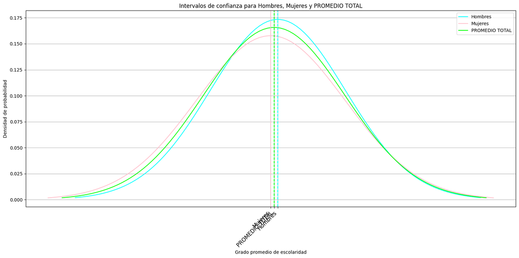

```python
import pandas as pd
import numpy as np
from scipy import stats

filas_inicio_fin = {
    2000: (15, 47),
    2010: (47, 79),
    2015: (79, 111),
    2020: (111, 143)
}

dataframes = {}
for year, (inicio, fin) in filas_inicio_fin.items():
    filas_a_omitir = inicio - 1
    dataframes[year] = pd.read_excel('Educacion_modificada.xlsx', skiprows=filas_a_omitir, nrows=fin - filas_a_omitir - 1, engine='openpyxl')

for year in [2010, 2015, 2020]:
    dataframes[year].columns = dataframes[2000].columns

df_2000 = dataframes[2000]
df_2010 = dataframes[2010]
df_2015 = dataframes[2015]
df_2020 = dataframes[2020]

df_combined = pd.concat([df_2000, df_2010, df_2015, df_2020])

def intervalo_confianza(data, alpha=0.05):
    media = np.mean(data)
    sem = stats.sem(data)
    intervalo = stats.t.interval(1-alpha, len(data)-1, loc=media, scale=sem)
    return media, intervalo

media_hombres, intervalo_hombres = intervalo_confianza(df_combined['Hombres'])
media_mujeres, intervalo_mujeres = intervalo_confianza(df_combined['Mujeres'])
media_total, intervalo_total = intervalo_confianza(df_combined['PROMEDIO TOTAL'])

print(f'\nIntervalo de confianza para Hombres: {intervalo_hombres}')
print(f'Intervalo de confianza para Mujeres: {intervalo_mujeres}')
print(f'Intervalo de confianza para PROMEDIO TOTAL: {intervalo_total}')

import matplotlib.pyplot as plt
from scipy.stats import norm

fig, ax = plt.subplots(figsize=(16, 8))

categorias = ['Hombres', 'Mujeres', 'PROMEDIO TOTAL']
medias = [media_hombres, media_mujeres, media_total]
errores = [(intervalo_hombres[1]-intervalo_hombres[0])/2,
           (intervalo_mujeres[1]-intervalo_mujeres[0])/2,
           (intervalo_total[1]-intervalo_total[0])/2]

colores = ['aqua', 'pink', 'lime']

for i, categoria in enumerate(categorias):
    media = medias[i]
    error = errores[i]
    desv = error * np.sqrt(len(df_combined))
    x = np.linspace(media - 3*desv, media + 3*desv, 100)
    y = norm.pdf(x, media, desv)
    ax.plot(x, y, label=categoria, color=colores[i])

for i, media in enumerate(medias):
    ax.axvline(media, color=colores[i], linestyle='--')

ax.set_xticks(medias)
ax.set_xticklabels(categorias, rotation=45, ha='right', fontsize=12)
ax.set_title('Intervalos de confianza para Hombres, Mujeres y PROMEDIO TOTAL')
ax.set_xlabel('Grado promedio de escolaridad')
ax.set_ylabel('Densidad de probabilidad')
ax.legend()
ax.grid(True)

plt.tight_layout()
plt.show()
```

5. Usando como referencia los de datos del archivo **Educacion_modificada.xlsx**

a) Realice una representación gráfica que involucre los intervalo de confianza usando el siguiente orden: *Hombres-2000*, *Mujeres-2000*, *Hombres-2010*, *Mujeres-2010*, *Hombres-2015*, *Mujeres-2015*, *Hombres-2020*, *Mujeres-2020* (donde se visualizen los intervalos en forma vertical y en una sola ventana de graficación.)

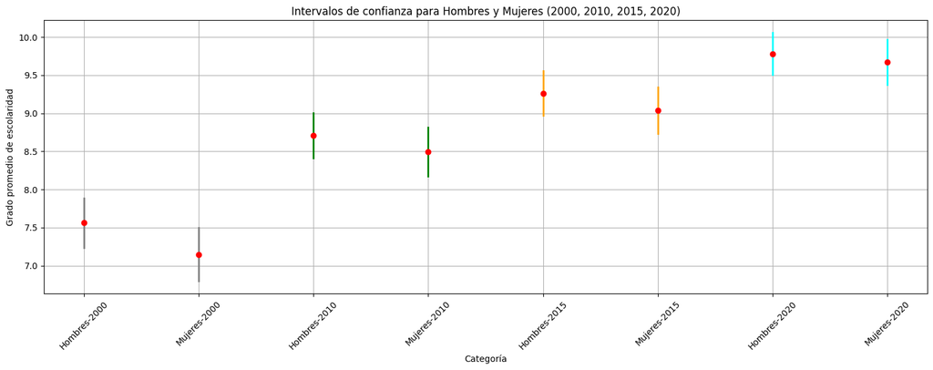

```python
import numpy as np
from scipy import stats
import matplotlib.pyplot as plt
from scipy.stats import norm

def intervalo_confianza(data, alpha=0.05):
    media = np.mean(data)
    sem = stats.sem(data)
    intervalo = stats.t.interval(1-alpha, len(data)-1, loc=media, scale=sem)
    return media, intervalo

media_hombres_2000, intervalo_hombres_2000 = intervalo_confianza(df_2000['Hombres'])
media_mujeres_2000, intervalo_mujeres_2000 = intervalo_confianza(df_2000['Mujeres'])

media_hombres_2010, intervalo_hombres_2010 = intervalo_confianza(df_2010['Hombres'])
media_mujeres_2010, intervalo_mujeres_2010 = intervalo_confianza(df_2010['Mujeres'])

media_hombres_2015, intervalo_hombres_2015 = intervalo_confianza(df_2015['Hombres'])
media_mujeres_2015, intervalo_mujeres_2015 = intervalo_confianza(df_2015['Mujeres'])

media_hombres_2020, intervalo_hombres_2020 = intervalo_confianza(df_2020['Hombres'])
media_mujeres_2020, intervalo_mujeres_2020 = intervalo_confianza(df_2020['Mujeres'])

fig = plt.figure(1, figsize=(15, 6))
ax = fig.add_subplot(111)

categorias = ['Hombres-2000', 'Mujeres-2000', 'Hombres-2010', 'Mujeres-2010', 'Hombres-2015', 'Mujeres-2015', 'Hombres-2020', 'Mujeres-2020']
medias = [media_hombres_2000, media_mujeres_2000, media_hombres_2010, media_mujeres_2010, media_hombres_2015, media_mujeres_2015, media_hombres_2020, media_mujeres_2020]
errores = [(intervalo_hombres_2000[1]-intervalo_hombres_2000[0])/2,
           (intervalo_mujeres_2000[1]-intervalo_mujeres_2000[0])/2,
           (intervalo_hombres_2010[1]-intervalo_hombres_2010[0])/2,
           (intervalo_mujeres_2010[1]-intervalo_mujeres_2010[0])/2,
           (intervalo_hombres_2015[1]-intervalo_hombres_2015[0])/2,
           (intervalo_mujeres_2015[1]-intervalo_mujeres_2015[0])/2,
           (intervalo_hombres_2020[1]-intervalo_hombres_2020[0])/2,
           (intervalo_mujeres_2020[1]-intervalo_mujeres_2020[0])/2]

colores = ['gray', 'gray', 'green', 'green', 'orange', 'orange', 'aqua', 'aqua']

for i in range(len(categorias)):
    ax.plot([i, i], [medias[i] - errores[i], medias[i] + errores[i]], color=colores[i], lw=2)
    ax.plot(i, medias[i], 'o', color='red')

ax.set_xticks(range(len(categorias)))
ax.set_xticklabels(categorias, rotation=45)
ax.set_title('Intervalos de confianza para Hombres y Mujeres (2000, 2010, 2015, 2020)')
ax.set_xlabel('Categoría')
ax.set_ylabel('Grado promedio de escolaridad')
ax.grid(True)

plt.tight_layout()
plt.show()
```